# Churn Analysis

```python
#installing the necessary packages if not pre-installed
#pip install pandas
#pip install plotly
#pip install seaborn
#pip install matplotlib
#pip install numpy
#!pip install nbformat
#!pip install chart_studio
#!pip install matplotlib-colorbar
#!pip install category_encoders
```

```python
#importing the necessary libraries
import pandas as pd
import numpy as np
import matplotlib.pyplot as plt
import plotly.express as px
from matplotlib.colors import LinearSegmentedColormap
import matplotlib.patches as patches
import seaborn as sns
import warnings
import category_encoders as ce

warnings.filterwarnings("ignore")
```

```python
#importing the e-commerce dataset into a dataframe
churn_raw = pd.read_csv(r"C:\Users\nithi\OneDrive - St. Clair College\303\LAB\assignment-1\New Churn Lab\E-Commerce Churn Data.csv")
churn_raw
```

|  | CustomerID | Churn | Tenure | PreferredLoginDevice | CityTier | WarehouseToHome | PreferredPaymentMode | Gender | HourSpendOnApp | NumberOfDeviceRegistered | PreferedOrderCat | SatisfactionScore | MaritalStatus | NumberOfAddress | Complain | OrderAmountHikeFromlastYear | CouponUsed | OrderCount | DaySinceLastOrder | CashbackAmount |
| --- | --- | --- | --- | --- | --- | --- | --- | --- | --- | --- | --- | --- | --- | --- | --- | --- | --- | --- | --- | --- |
| 0 | 50001 | 1 | 4.00 | Mobile Phone | 3 | 6.00 | Debit Card | Female | 3.00 | 3 | Laptop & Accessory | 2 | Single | 9 | 1 | 11.00 | 1.00 | 1.00 | 5.00 | 160 |
| 1 | 50002 | 1 | NaN | Phone | 1 | 8.00 | UPI | Male | 3.00 | 4 | Mobile | 3 | Single | 7 | 1 | 15.00 | 0.00 | 1.00 | 0.00 | 121 |
| 2 | 50003 | 1 | NaN | Phone | 1 | 30.00 | Debit Card | Male | 2.00 | 4 | Mobile | 3 | Single | 6 | 1 | 14.00 | 0.00 | 1.00 | 3.00 | 120 |
| 3 | 50004 | 1 | 0.00 | Phone | 3 | 15.00 | Debit Card | Male | 2.00 | 4 | Laptop & Accessory | 5 | Single | 8 | 0 | 23.00 | 0.00 | 1.00 | 3.00 | 134 |
| 4 | 50005 | 1 | 0.00 | Phone | 1 | 12.00 | CC | Male | NaN | 3 | Mobile | 5 | Single | 3 | 0 | 11.00 | 1.00 | 1.00 | 3.00 | 130 |
| ... | ... | ... | ... | ... | ... | ... | ... | ... | ... | ... | ... | ... | ... | ... | ... | ... | ... | ... | ... | ... |
| 5625 | 55626 | 0 | 10.00 | Computer | 1 | 30.00 | Credit Card | Male | 3.00 | 2 | Laptop & Accessory | 1 | Married | 6 | 0 | 18.00 | 1.00 | 2.00 | 4.00 | 151 |
| 5626 | 55627 | 0 | 13.00 | Mobile Phone | 1 | 13.00 | Credit Card | Male | 3.00 | 5 | Fashion | 5 | Married | 6 | 0 | 16.00 | 1.00 | 2.00 | NaN | 225 |
| 5627 | 55628 | 0 | 1.00 | Mobile Phone | 1 | 11.00 | Debit Card | Male | 3.00 | 2 | Laptop & Accessory | 4 | Married | 3 | 1 | 21.00 | 1.00 | 2.00 | 4.00 | 186 |
| 5628 | 55629 | 0 | 23.00 | Computer | 3 | 9.00 | Credit Card | Male | 4.00 | 5 | Laptop & Accessory | 4 | Married | 4 | 0 | 15.00 | 2.00 | 2.00 | 9.00 | 179 |
| 5629 | 55630 | 0 | 8.00 | Mobile Phone | 1 | 15.00 | Credit Card | Male | 3.00 | 2 | Laptop & Accessory | 3 | Married | 4 | 0 | 13.00 | 2.00 | 2.00 | 3.00 | 169 |

5630 rows × 20 columns

```python
#checking the column names
churn_raw.columns
```

```
Index(['CustomerID', 'Churn', 'Tenure', 'PreferredLoginDevice', 'CityTier',
       'WarehouseToHome', 'PreferredPaymentMode', 'Gender', 'HourSpendOnApp',
       'NumberOfDeviceRegistered', 'PreferedOrderCat', 'SatisfactionScore',
       'MaritalStatus', 'NumberOfAddress', 'Complain',
       'OrderAmountHikeFromlastYear', 'CouponUsed', 'OrderCount',
       'DaySinceLastOrder', 'CashbackAmount'],
      dtype='object')
```

```python
#checking the description of dataset
pd.options.display.float_format = '{:20,.2f}'.format
churn_raw.describe().T
```

|  | count | mean | std | min | 25% | 50% | 75% | max |
| --- | --- | --- | --- | --- | --- | --- | --- | --- |
| CustomerID | 5,630.00 | 52,815.50 | 1,625.39 | 50,001.00 | 51,408.25 | 52,815.50 | 54,222.75 | 55,630.00 |
| Churn | 5,630.00 | 0.17 | 0.37 | 0.00 | 0.00 | 0.00 | 0.00 | 1.00 |
| Tenure | 5,366.00 | 10.19 | 8.56 | 0.00 | 2.00 | 9.00 | 16.00 | 61.00 |
| CityTier | 5,630.00 | 1.65 | 0.92 | 1.00 | 1.00 | 1.00 | 3.00 | 3.00 |
| WarehouseToHome | 5,379.00 | 15.64 | 8.53 | 5.00 | 9.00 | 14.00 | 20.00 | 127.00 |
| HourSpendOnApp | 5,375.00 | 2.93 | 0.72 | 0.00 | 2.00 | 3.00 | 3.00 | 5.00 |
| NumberOfDeviceRegistered | 5,630.00 | 3.69 | 1.02 | 1.00 | 3.00 | 4.00 | 4.00 | 6.00 |
| SatisfactionScore | 5,630.00 | 3.07 | 1.38 | 1.00 | 2.00 | 3.00 | 4.00 | 5.00 |
| NumberOfAddress | 5,630.00 | 4.21 | 2.58 | 1.00 | 2.00 | 3.00 | 6.00 | 22.00 |
| Complain | 5,630.00 | 0.28 | 0.45 | 0.00 | 0.00 | 0.00 | 1.00 | 1.00 |
| OrderAmountHikeFromlastYear | 5,365.00 | 15.71 | 3.68 | 11.00 | 13.00 | 15.00 | 18.00 | 26.00 |
| CouponUsed | 5,374.00 | 1.75 | 1.89 | 0.00 | 1.00 | 1.00 | 2.00 | 16.00 |
| OrderCount | 5,372.00 | 3.01 | 2.94 | 1.00 | 1.00 | 2.00 | 3.00 | 16.00 |
| DaySinceLastOrder | 5,323.00 | 4.54 | 3.65 | 0.00 | 2.00 | 3.00 | 7.00 | 46.00 |
| CashbackAmount | 5,630.00 | 177.22 | 49.19 | 0.00 | 146.00 | 163.00 | 196.00 | 325.00 |

```python
#checking the first 10 records of the dataset
churn_raw.head(10)
```

|  | CustomerID | Churn | Tenure | PreferredLoginDevice | CityTier | WarehouseToHome | PreferredPaymentMode | Gender | HourSpendOnApp | NumberOfDeviceRegistered | PreferedOrderCat | SatisfactionScore | MaritalStatus | NumberOfAddress | Complain | OrderAmountHikeFromlastYear | CouponUsed | OrderCount | DaySinceLastOrder | CashbackAmount |
| --- | --- | --- | --- | --- | --- | --- | --- | --- | --- | --- | --- | --- | --- | --- | --- | --- | --- | --- | --- | --- |
| 0 | 50001 | 1 | 4.00 | Mobile Phone | 3 | 6.00 | Debit Card | Female | 3.00 | 3 | Laptop & Accessory | 2 | Single | 9 | 1 | 11.00 | 1.00 | 1.00 | 5.00 | 160 |
| 1 | 50002 | 1 | NaN | Phone | 1 | 8.00 | UPI | Male | 3.00 | 4 | Mobile | 3 | Single | 7 | 1 | 15.00 | 0.00 | 1.00 | 0.00 | 121 |
| 2 | 50003 | 1 | NaN | Phone | 1 | 30.00 | Debit Card | Male | 2.00 | 4 | Mobile | 3 | Single | 6 | 1 | 14.00 | 0.00 | 1.00 | 3.00 | 120 |
| 3 | 50004 | 1 | 0.00 | Phone | 3 | 15.00 | Debit Card | Male | 2.00 | 4 | Laptop & Accessory | 5 | Single | 8 | 0 | 23.00 | 0.00 | 1.00 | 3.00 | 134 |
| 4 | 50005 | 1 | 0.00 | Phone | 1 | 12.00 | CC | Male | NaN | 3 | Mobile | 5 | Single | 3 | 0 | 11.00 | 1.00 | 1.00 | 3.00 | 130 |
| 5 | 50006 | 1 | 0.00 | Computer | 1 | 22.00 | Debit Card | Female | 3.00 | 5 | Mobile Phone | 5 | Single | 2 | 1 | 22.00 | 4.00 | 6.00 | 7.00 | 139 |
| 6 | 50007 | 1 | NaN | Phone | 3 | 11.00 | Cash on Delivery | Male | 2.00 | 3 | Laptop & Accessory | 2 | Divorced | 4 | 0 | 14.00 | 0.00 | 1.00 | 0.00 | 121 |
| 7 | 50008 | 1 | NaN | Phone | 1 | 6.00 | CC | Male | 3.00 | 3 | Mobile | 2 | Divorced | 3 | 1 | 16.00 | 2.00 | 2.00 | 0.00 | 123 |
| 8 | 50009 | 1 | 13.00 | Phone | 3 | 9.00 | E wallet | Male | NaN | 4 | Mobile | 3 | Divorced | 2 | 1 | 14.00 | 0.00 | 1.00 | 2.00 | 127 |
| 9 | 50010 | 1 | NaN | Phone | 1 | 31.00 | Debit Card | Male | 2.00 | 5 | Mobile | 3 | Single | 2 | 0 | 12.00 | 1.00 | 1.00 | 1.00 | 123 |

```python
#checking the shape of our dataset
churn_raw.shape
```

```
(5630, 20)
```

```python
#checking the dataset information
churn_raw.info()
```

```
<class 'pandas.core.frame.DataFrame'>
RangeIndex: 5630 entries, 0 to 5629
Data columns (total 20 columns):
 #   Column                       Non-Null Count  Dtype
---  ------                       --------------  -----
 0   CustomerID                   5630 non-null   int64
 1   Churn                        5630 non-null   int64
 2   Tenure                       5366 non-null   float64
 3   PreferredLoginDevice         5630 non-null   object
 4   CityTier                     5630 non-null   int64
 5   WarehouseToHome              5379 non-null   float64
 6   PreferredPaymentMode         5630 non-null   object
 7   Gender                       5630 non-null   object
 8   HourSpendOnApp               5375 non-null   float64
 9   NumberOfDeviceRegistered     5630 non-null   int64
 10  PreferedOrderCat             5630 non-null   object
 11  SatisfactionScore            5630 non-null   int64
 12  MaritalStatus                5630 non-null   object
 13  NumberOfAddress              5630 non-null   int64
 14  Complain                     5630 non-null   int64
 15  OrderAmountHikeFromlastYear  5365 non-null   float64
 16  CouponUsed                   5374 non-null   float64
 17  OrderCount                   5372 non-null   float64
 18  DaySinceLastOrder            5323 non-null   float64
 19  CashbackAmount               5630 non-null   int64
dtypes: float64(7), int64(8), object(5)
memory usage: 879.8+ KB
```

```python
#Detectung missing values
churn_raw.isnull().any()
```

```
CustomerID                     False
Churn                          False
Tenure                          True
PreferredLoginDevice           False
CityTier                       False
WarehouseToHome                 True
PreferredPaymentMode           False
Gender                         False
HourSpendOnApp                  True
NumberOfDeviceRegistered       False
PreferedOrderCat               False
SatisfactionScore              False
MaritalStatus                  False
NumberOfAddress                False
Complain                       False
OrderAmountHikeFromlastYear     True
CouponUsed                      True
OrderCount                      True
DaySinceLastOrder               True
CashbackAmount                 False
dtype: bool
```

```python
#counting the missing values
churn_raw.isna().sum()
```

```
CustomerID                       0
Churn                            0
Tenure                         264
PreferredLoginDevice             0
CityTier                         0
WarehouseToHome                251
PreferredPaymentMode             0
Gender                           0
HourSpendOnApp                 255
NumberOfDeviceRegistered         0
PreferedOrderCat                 0
SatisfactionScore                0
MaritalStatus                    0
NumberOfAddress                  0
Complain                         0
OrderAmountHikeFromlastYear    265
CouponUsed                     256
OrderCount                     258
DaySinceLastOrder              307
CashbackAmount                   0
dtype: int64
```

```python
#total number of missing values in our dataset
churn_raw.isna().sum().sum()
```

```
1856
```

```python
import pandas as pd

def dataframe_description(df):
    """
    This function takes a pandas DataFrame as input and returns a new DataFrame
    with information about each column:
        data type,
        percentage of missing values,
        number of unique values,
        and the unique values themselves.
    """
    with pd.option_context("display.max_colwidth", 20):
        info = pd.DataFrame()
        info['data type'] = df.dtypes
        info['percent missing'] = df.isnull().sum() * 100 / len(df)
        info['No. unique'] = df.nunique()
        info['unique values'] = df.apply(lambda x: ', '.join(map(str, x.unique())))

        return info.sort_values('data type')
```

```python
dataframe_description(churn_raw)
```

|  | data type | percent missing | No. unique | unique values |
| --- | --- | --- | --- | --- |
| CustomerID | int64 | 0.00 | 5630 | 50001, 50002, 50003, 50004, 50005, 50006, 5000... |
| Complain | int64 | 0.00 | 2 | 1, 0 |
| NumberOfAddress | int64 | 0.00 | 15 | 9, 7, 6, 8, 3, 2, 4, 10, 1, 5, 19, 21, 11, 20, 22 |
| SatisfactionScore | int64 | 0.00 | 5 | 2, 3, 5, 4, 1 |
| NumberOfDeviceRegistered | int64 | 0.00 | 6 | 3, 4, 5, 2, 1, 6 |
| Churn | int64 | 0.00 | 2 | 1, 0 |
| CityTier | int64 | 0.00 | 3 | 3, 1, 2 |
| CashbackAmount | int64 | 0.00 | 220 | 160, 121, 120, 134, 130, 139, 123, 127, 295, 1... |
| WarehouseToHome | float64 | 4.46 | 34 | 6.0, 8.0, 30.0, 15.0, 12.0, 22.0, 11.0, 9.0, 3... |
| HourSpendOnApp | float64 | 4.53 | 6 | 3.0, 2.0, nan, 1.0, 0.0, 4.0, 5.0 |
| DaySinceLastOrder | float64 | 5.45 | 22 | 5.0, 0.0, 3.0, 7.0, 2.0, 1.0, 8.0, 6.0, 4.0, 1... |
| Tenure | float64 | 4.69 | 36 | 4.0, nan, 0.0, 13.0, 11.0, 9.0, 19.0, 20.0, 14... |
| OrderAmountHikeFromlastYear | float64 | 4.71 | 16 | 11.0, 15.0, 14.0, 23.0, 22.0, 16.0, 12.0, nan,... |
| CouponUsed | float64 | 4.55 | 17 | 1.0, 0.0, 4.0, 2.0, 9.0, 6.0, 11.0, nan, 7.0, ... |
| OrderCount | float64 | 4.58 | 16 | 1.0, 6.0, 2.0, 15.0, 4.0, 7.0, 3.0, 9.0, nan, ... |
| PreferredPaymentMode | object | 0.00 | 7 | Debit Card, UPI, CC, Cash on Delivery, E walle... |
| Gender | object | 0.00 | 2 | Female, Male |
| PreferedOrderCat | object | 0.00 | 6 | Laptop & Accessory, Mobile, Mobile Phone, Othe... |
| PreferredLoginDevice | object | 0.00 | 3 | Mobile Phone, Phone, Computer |
| MaritalStatus | object | 0.00 | 3 | Single, Divorced, Married |

```python
#creating a function to find the columns with missing values, extract the number and percentage of these missing values in relation to the dataset
def FindMissingColsPercentage(df):
    missing_cols = [(col, df[col].isnull().sum(), round(df[col].isnull().mean() * 100, 2)) for col in df.columns if df[col].isnull().sum() != 0]
    if missing_cols:
        for col, count, pct in missing_cols:
            print('{} => {} [{}%]'.format(col, count, pct))
    else:
        print("no missing values")
```

```python
FindMissingColsPercentage(churn_raw)
```

```
Tenure => 264 [4.69%]
WarehouseToHome => 251 [4.46%]
HourSpendOnApp => 255 [4.53%]
OrderAmountHikeFromlastYear => 265 [4.71%]
CouponUsed => 256 [4.55%]
OrderCount => 258 [4.58%]
DaySinceLastOrder => 307 [5.45%]
```

### Data Cleaning

```python
#replacing all empty spaces with np.NaN
churn_clean = churn_raw.replace(" ", np.NaN)
```

```python
# replacing all missing values(NaN) in the dataset with 0
churn_clean = churn_clean.fillna(0)
```

```python
#checking dataset information after replacing the missing values
churn_clean.info()
```

```
<class 'pandas.core.frame.DataFrame'>
RangeIndex: 5630 entries, 0 to 5629
Data columns (total 20 columns):
 #   Column                       Non-Null Count  Dtype
---  ------                       --------------  -----
 0   CustomerID                   5630 non-null   int64
 1   Churn                        5630 non-null   int64
 2   Tenure                       5630 non-null   float64
 3   PreferredLoginDevice         5630 non-null   object
 4   CityTier                     5630 non-null   int64
 5   WarehouseToHome              5630 non-null   float64
 6   PreferredPaymentMode         5630 non-null   object
 7   Gender                       5630 non-null   object
 8   HourSpendOnApp               5630 non-null   float64
 9   NumberOfDeviceRegistered     5630 non-null   int64
 10  PreferedOrderCat             5630 non-null   object
 11  SatisfactionScore            5630 non-null   int64
 12  MaritalStatus                5630 non-null   object
 13  NumberOfAddress              5630 non-null   int64
 14  Complain                     5630 non-null   int64
 15  OrderAmountHikeFromlastYear  5630 non-null   float64
 16  CouponUsed                   5630 non-null   float64
 17  OrderCount                   5630 non-null   float64
 18  DaySinceLastOrder            5630 non-null   float64
 19  CashbackAmount               5630 non-null   int64
dtypes: float64(7), int64(8), object(5)
memory usage: 879.8+ KB
```

```python
churn_clean.isnull().any()
```

```
CustomerID                     False
Churn                          False
Tenure                         False
PreferredLoginDevice           False
CityTier                       False
WarehouseToHome                False
PreferredPaymentMode           False
Gender                         False
HourSpendOnApp                 False
NumberOfDeviceRegistered       False
PreferedOrderCat               False
SatisfactionScore              False
MaritalStatus                  False
NumberOfAddress                False
Complain                       False
OrderAmountHikeFromlastYear    False
CouponUsed                     False
OrderCount                     False
DaySinceLastOrder              False
CashbackAmount                 False
dtype: bool
```

```python
FindMissingColsPercentage(churn_clean)
```

```
no missing values
```

```python
#viewing the object data type columns
churn_clean[['PreferredPaymentMode', 'Gender', 'PreferedOrderCat', 'PreferredLoginDevice', 'MaritalStatus']]
```

|  | PreferredPaymentMode | Gender | PreferedOrderCat | PreferredLoginDevice | MaritalStatus |
| --- | --- | --- | --- | --- | --- |
| 0 | Debit Card | Female | Laptop & Accessory | Mobile Phone | Single |
| 1 | UPI | Male | Mobile | Phone | Single |
| 2 | Debit Card | Male | Mobile | Phone | Single |
| 3 | Debit Card | Male | Laptop & Accessory | Phone | Single |
| 4 | CC | Male | Mobile | Phone | Single |
| ... | ... | ... | ... | ... | ... |
| 5625 | Credit Card | Male | Laptop & Accessory | Computer | Married |
| 5626 | Credit Card | Male | Fashion | Mobile Phone | Married |
| 5627 | Debit Card | Male | Laptop & Accessory | Mobile Phone | Married |
| 5628 | Credit Card | Male | Laptop & Accessory | Computer | Married |
| 5629 | Credit Card | Male | Laptop & Accessory | Mobile Phone | Married |

5630 rows × 5 columns

# Data manipulation

```python
import pandas as pd
import numpy as np

# assume 'data' is your DataFrame

# create a new column 'cashback_grp' with cashback groups
churn_clean['cashback_grp'] = pd.cut(churn_clean['CashbackAmount'],
                             bins=[0, 100, 201, 301, np.inf],
                             labels=['0-99', '100-200', '201-300', '301+'])

# print the resulting DataFrame
churn_clean.head()
```

|  | CustomerID | Churn | Tenure | PreferredLoginDevice | CityTier | WarehouseToHome | PreferredPaymentMode | Gender | HourSpendOnApp | NumberOfDeviceRegistered | ... | SatisfactionScore | MaritalStatus | NumberOfAddress | Complain | OrderAmountHikeFromlastYear | CouponUsed | OrderCount | DaySinceLastOrder | CashbackAmount | cashback_grp |
| --- | --- | --- | --- | --- | --- | --- | --- | --- | --- | --- | --- | --- | --- | --- | --- | --- | --- | --- | --- | --- | --- |
| 0 | 50001 | 1 | 4.00 | Mobile Phone | 3 | 6.00 | Debit Card | Female | 3.00 | 3 | ... | 2 | Single | 9 | 1 | 11.00 | 1.00 | 1.00 | 5.00 | 160 | 100-200 |
| 1 | 50002 | 1 | 0.00 | Phone | 1 | 8.00 | UPI | Male | 3.00 | 4 | ... | 3 | Single | 7 | 1 | 15.00 | 0.00 | 1.00 | 0.00 | 121 | 100-200 |
| 2 | 50003 | 1 | 0.00 | Phone | 1 | 30.00 | Debit Card | Male | 2.00 | 4 | ... | 3 | Single | 6 | 1 | 14.00 | 0.00 | 1.00 | 3.00 | 120 | 100-200 |
| 3 | 50004 | 1 | 0.00 | Phone | 3 | 15.00 | Debit Card | Male | 2.00 | 4 | ... | 5 | Single | 8 | 0 | 23.00 | 0.00 | 1.00 | 3.00 | 134 | 100-200 |
| 4 | 50005 | 1 | 0.00 | Phone | 1 | 12.00 | CC | Male | 0.00 | 3 | ... | 5 | Single | 3 | 0 | 11.00 | 1.00 | 1.00 | 3.00 | 130 | 100-200 |

5 rows × 21 columns

```python
#checking the unique values in these columns
obj = ['PreferredPaymentMode', 'Gender', 'PreferedOrderCat', 'PreferredLoginDevice', 'MaritalStatus']  #creating a list to the column names

for i in obj: #creating a for loop to print out the column name and unique values and count
    print(churn_clean[i].value_counts(),'\n')
```

```
PreferredPaymentMode
Debit Card          2314
Credit Card         1501
E wallet             614
UPI                  414
COD                  365
CC                   273
Cash on Delivery     149
Name: count, dtype: int64

Gender
Male      3384
Female    2246
Name: count, dtype: int64

PreferedOrderCat
Laptop & Accessory    2050
Mobile Phone          1271
Fashion                826
Mobile                 809
Grocery                410
Others                 264
Name: count, dtype: int64

PreferredLoginDevice
Mobile Phone    2765
Computer        1634
Phone           1231
Name: count, dtype: int64

MaritalStatus
Married     2986
Single      1796
Divorced     848
Name: count, dtype: int64
```

After reviewing the unique values in the specified columns, we can infer the following:

- In the PreferredPaymentMode column, 'CC' refers to 'Credit Card,' and 'COD' refers to 'Cash on Delivery.'
- In the PreferredLoginDevice column, both 'Mobile' and 'Phone' are synonymous and can be considered the same.
- In the PreferedOrderCat column, 'Mobile' and 'Mobile Phone' are used interchangeably.

Therefore, we are cleaning the data by making the following replacements:

- Replaced 'CC' with 'Credit Card'
- Replaced 'COD' with 'Cash on Delivery'
- Replaced 'Phone' with 'Mobile Phone'
- Replaced 'Mobile' with 'Mobile Phone'

```python
#replacing the data entries that has the same meaning
churn_clean['PreferredPaymentMode'] = churn_clean['PreferredPaymentMode'].replace('CC', 'Credit Card')
churn_clean['PreferredPaymentMode'] = churn_clean['PreferredPaymentMode'].replace('COD', 'Cash on Delivery')
churn_clean['PreferedOrderCat'] = churn_clean['PreferedOrderCat'].replace('Mobile', 'Mobile Phone')
churn_clean['PreferredLoginDevice'] = churn_clean['PreferredLoginDevice'].replace('Phone', 'Mobile Phone')
```

```python
#cross-checking the replacement has been effected
for i in obj: #creating a for loop to print out the column name and unique values and count
    print(churn_clean[i].value_counts(),'\n')
```

```
PreferredPaymentMode
Debit Card          2314
Credit Card         1774
E wallet             614
Cash on Delivery     514
UPI                  414
Name: count, dtype: int64

Gender
Male      3384
Female    2246
Name: count, dtype: int64

PreferedOrderCat
Mobile Phone          2080
Laptop & Accessory    2050
Fashion                826
Grocery                410
Others                 264
Name: count, dtype: int64

PreferredLoginDevice
Mobile Phone    3996
Computer        1634
Name: count, dtype: int64

MaritalStatus
Married     2986
Single      1796
Divorced     848
Name: count, dtype: int64
```

```python
#creating categories from tenure column into a new column - tenuregroup for identifying customer segments and analyzinf churn behavior
ranges = [0,10,20,30,40,50,60,np.inf] #list to hold the bin ranges
group_names = ['0-10 years', '11-20 years', '21-30 years', '31-40 years', '41-50 years', '51-60 years', '61 years & above'] # list to hold the labels
churn_clean['TenureGroup'] = pd.cut(churn_clean['Tenure'], bins = ranges, labels = group_names, include_lowest = True)
churn_clean[['Tenure', 'TenureGroup']]
```

|  | Tenure | TenureGroup |
| --- | --- | --- |
| 0 | 4.00 | 0-10 years |
| 1 | 0.00 | 0-10 years |
| 2 | 0.00 | 0-10 years |
| 3 | 0.00 | 0-10 years |
| 4 | 0.00 | 0-10 years |
| ... | ... | ... |
| 5625 | 10.00 | 0-10 years |
| 5626 | 13.00 | 11-20 years |
| 5627 | 1.00 | 0-10 years |
| 5628 | 23.00 | 21-30 years |
| 5629 | 8.00 | 0-10 years |

5630 rows × 2 columns

```python
#checking the final clean data
churn_clean.head(20)
```

|  | CustomerID | Churn | Tenure | PreferredLoginDevice | CityTier | WarehouseToHome | PreferredPaymentMode | Gender | HourSpendOnApp | NumberOfDeviceRegistered | ... | MaritalStatus | NumberOfAddress | Complain | OrderAmountHikeFromlastYear | CouponUsed | OrderCount | DaySinceLastOrder | CashbackAmount | cashback_grp | TenureGroup |
| --- | --- | --- | --- | --- | --- | --- | --- | --- | --- | --- | --- | --- | --- | --- | --- | --- | --- | --- | --- | --- | --- |
| 0 | 50001 | 1 | 4.00 | Mobile Phone | 3 | 6.00 | Debit Card | Female | 3.00 | 3 | ... | Single | 9 | 1 | 11.00 | 1.00 | 1.00 | 5.00 | 160 | 100-200 | 0-10 years |
| 1 | 50002 | 1 | 0.00 | Mobile Phone | 1 | 8.00 | UPI | Male | 3.00 | 4 | ... | Single | 7 | 1 | 15.00 | 0.00 | 1.00 | 0.00 | 121 | 100-200 | 0-10 years |
| 2 | 50003 | 1 | 0.00 | Mobile Phone | 1 | 30.00 | Debit Card | Male | 2.00 | 4 | ... | Single | 6 | 1 | 14.00 | 0.00 | 1.00 | 3.00 | 120 | 100-200 | 0-10 years |
| 3 | 50004 | 1 | 0.00 | Mobile Phone | 3 | 15.00 | Debit Card | Male | 2.00 | 4 | ... | Single | 8 | 0 | 23.00 | 0.00 | 1.00 | 3.00 | 134 | 100-200 | 0-10 years |
| 4 | 50005 | 1 | 0.00 | Mobile Phone | 1 | 12.00 | Credit Card | Male | 0.00 | 3 | ... | Single | 3 | 0 | 11.00 | 1.00 | 1.00 | 3.00 | 130 | 100-200 | 0-10 years |
| 5 | 50006 | 1 | 0.00 | Computer | 1 | 22.00 | Debit Card | Female | 3.00 | 5 | ... | Single | 2 | 1 | 22.00 | 4.00 | 6.00 | 7.00 | 139 | 100-200 | 0-10 years |
| 6 | 50007 | 1 | 0.00 | Mobile Phone | 3 | 11.00 | Cash on Delivery | Male | 2.00 | 3 | ... | Divorced | 4 | 0 | 14.00 | 0.00 | 1.00 | 0.00 | 121 | 100-200 | 0-10 years |
| 7 | 50008 | 1 | 0.00 | Mobile Phone | 1 | 6.00 | Credit Card | Male | 3.00 | 3 | ... | Divorced | 3 | 1 | 16.00 | 2.00 | 2.00 | 0.00 | 123 | 100-200 | 0-10 years |
| 8 | 50009 | 1 | 13.00 | Mobile Phone | 3 | 9.00 | E wallet | Male | 0.00 | 4 | ... | Divorced | 2 | 1 | 14.00 | 0.00 | 1.00 | 2.00 | 127 | 100-200 | 11-20 years |
| 9 | 50010 | 1 | 0.00 | Mobile Phone | 1 | 31.00 | Debit Card | Male | 2.00 | 5 | ... | Single | 2 | 0 | 12.00 | 1.00 | 1.00 | 1.00 | 123 | 100-200 | 0-10 years |
| 10 | 50011 | 1 | 4.00 | Mobile Phone | 1 | 18.00 | Cash on Delivery | Female | 2.00 | 3 | ... | Divorced | 2 | 0 | 0.00 | 9.00 | 15.00 | 8.00 | 295 | 201-300 | 0-10 years |
| 11 | 50012 | 1 | 11.00 | Mobile Phone | 1 | 6.00 | Debit Card | Male | 3.00 | 4 | ... | Single | 10 | 1 | 13.00 | 0.00 | 1.00 | 0.00 | 154 | 100-200 | 11-20 years |
| 12 | 50013 | 1 | 0.00 | Mobile Phone | 1 | 11.00 | Cash on Delivery | Male | 2.00 | 3 | ... | Single | 2 | 1 | 13.00 | 2.00 | 2.00 | 2.00 | 134 | 100-200 | 0-10 years |
| 13 | 50014 | 1 | 0.00 | Mobile Phone | 1 | 15.00 | Credit Card | Male | 3.00 | 4 | ... | Divorced | 1 | 1 | 17.00 | 0.00 | 1.00 | 0.00 | 134 | 100-200 | 0-10 years |
| 14 | 50015 | 1 | 9.00 | Mobile Phone | 3 | 15.00 | Credit Card | Male | 3.00 | 4 | ... | Single | 2 | 0 | 16.00 | 0.00 | 4.00 | 7.00 | 196 | 100-200 | 0-10 years |
| 15 | 50016 | 1 | 0.00 | Mobile Phone | 2 | 12.00 | UPI | Male | 3.00 | 3 | ... | Married | 5 | 1 | 22.00 | 1.00 | 1.00 | 2.00 | 121 | 100-200 | 0-10 years |
| 16 | 50017 | 1 | 0.00 | Computer | 1 | 12.00 | Debit Card | Female | 0.00 | 4 | ... | Single | 2 | 1 | 18.00 | 1.00 | 1.00 | 0.00 | 129 | 100-200 | 0-10 years |
| 17 | 50018 | 1 | 0.00 | Mobile Phone | 3 | 11.00 | E wallet | Male | 2.00 | 4 | ... | Single | 2 | 1 | 11.00 | 1.00 | 1.00 | 3.00 | 157 | 100-200 | 0-10 years |
| 18 | 50019 | 1 | 0.00 | Computer | 1 | 13.00 | Debit Card | Male | 3.00 | 5 | ... | Single | 2 | 1 | 24.00 | 1.00 | 1.00 | 6.00 | 161 | 100-200 | 0-10 years |
| 19 | 50020 | 1 | 19.00 | Mobile Phone | 1 | 20.00 | Debit Card | Female | 3.00 | 3 | ... | Divorced | 10 | 1 | 18.00 | 1.00 | 4.00 | 3.00 | 150 | 100-200 | 11-20 years |

20 rows × 22 columns

### Exploratory Data Analysis

```
array([[<Axes: title={'center': 'HourSpendOnApp'}>,
        <Axes: title={'center': 'NumberOfDeviceRegistered'}>],
       [<Axes: title={'center': 'SatisfactionScore'}>,
        <Axes: title={'center': 'OrderAmountHikeFromlastYear'}>],
       [<Axes: title={'center': 'CouponUsed'}>,
        <Axes: title={'center': 'DaySinceLastOrder'}>]], dtype=object)
```

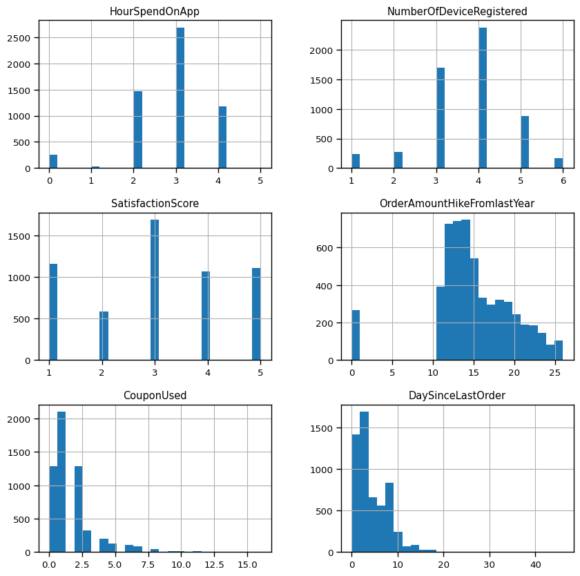

```python
# Plotting graphs for better understanding of data distribution

cols = ['HourSpendOnApp', 'NumberOfDeviceRegistered', 'SatisfactionScore', 'OrderAmountHikeFromlastYear', 'CouponUsed', 'DaySinceLastOrder']
churn_clean[cols].hist(figsize=(10,10), bins=25)
```

```
NormaltestResult(statistic=853.0786436508163, pvalue=5.7059270703286084e-186)
```

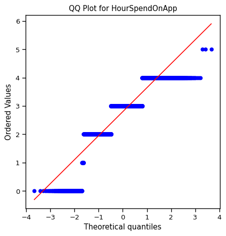

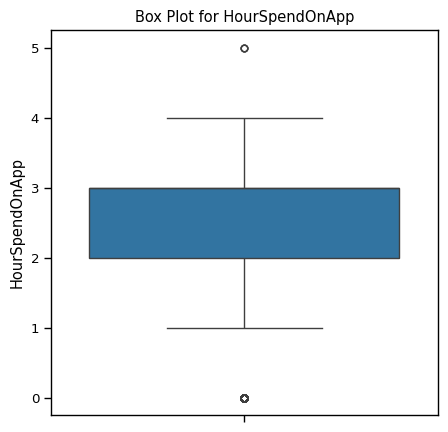

```
NormaltestResult(statistic=187.2337858347555, pvalue=2.201405225625609e-41)
```

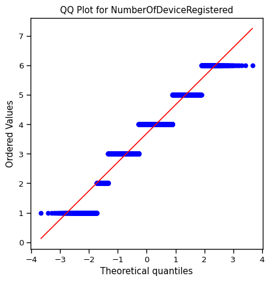

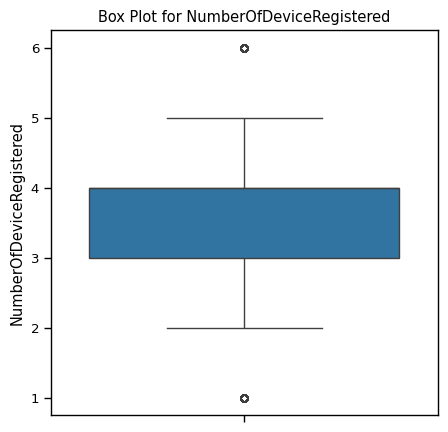

```
NormaltestResult(statistic=2713.032518618546, pvalue=0.0)
```

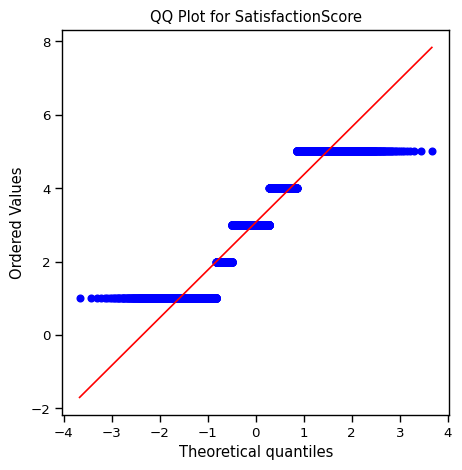

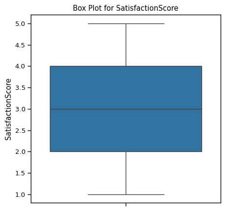

```
NormaltestResult(statistic=749.2174865448721, pvalue=2.039341344936956e-163)
```

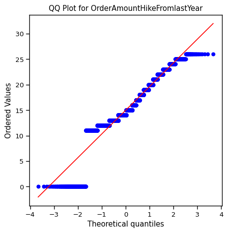

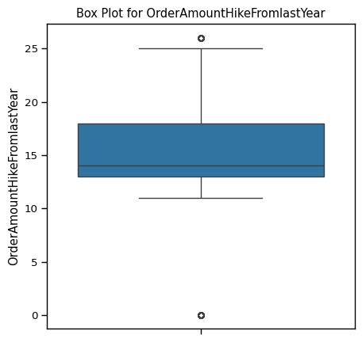

```
NormaltestResult(statistic=1345.6468436995592, pvalue=6.258937219623144e-293)
```

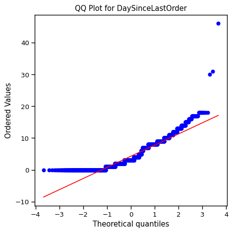

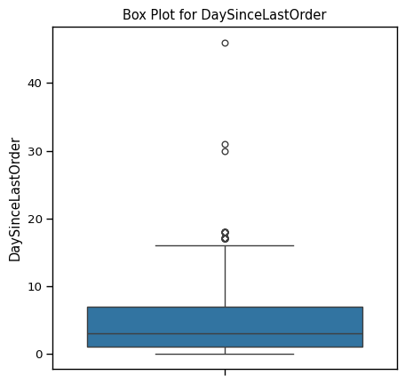

```python
import scipy.stats as stats
import seaborn as sns
import matplotlib.pyplot as plt

# For continuous variables
continuous_cols = ['HourSpendOnApp', 'NumberOfDeviceRegistered', 'SatisfactionScore', 'OrderAmountHikeFromlastYear', 'DaySinceLastOrder']  # Replace with your continuous columns
for col in continuous_cols:
    # Normality test
    print(stats.normaltest(churn_clean[col]))

    # QQ plot
    plt.figure(figsize=(5,5))
    stats.probplot(churn_clean[col], dist="norm", plot=plt)
    plt.title(f"QQ Plot for {col}")
    plt.show()

    # Box plot
    plt.figure(figsize=(5,5))
    sns.boxplot(churn_clean[col])
    plt.title(f"Box Plot for {col}")
    plt.show()
```

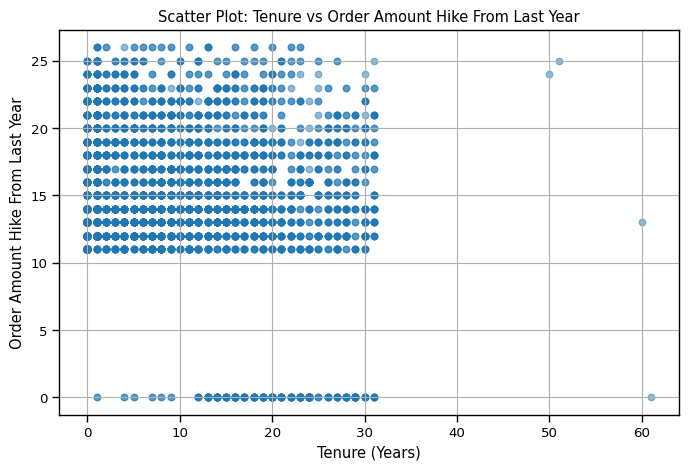

```python
plt.figure(figsize=(8,5))
plt.scatter(churn_clean['Tenure'], churn_clean['OrderAmountHikeFromlastYear'], alpha=0.5)
plt.title('Scatter Plot: Tenure vs Order Amount Hike From Last Year')
plt.xlabel('Tenure (Years)')
plt.ylabel('Order Amount Hike From Last Year')
plt.grid(True)
plt.show()
```

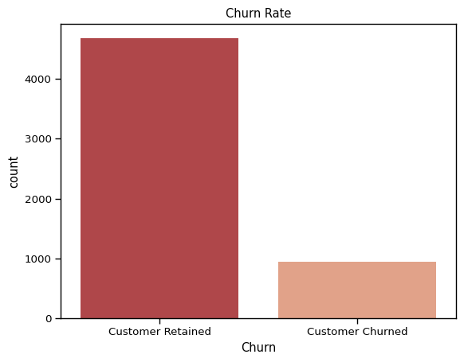

```python
churn_1 =  churn_clean.copy() #creating a copy of the cleaned dataset
churn_labels = {0: "Customer Retained", 1: "Customer Churned"} #creating a dictionary for the churn labels
churn_1['Churn'] = churn_1['Churn'].replace(churn_labels) #replacing the binary numbers in the column to the new churn labels

#visualising customer churn rate
sns.countplot(x = 'Churn', data = churn_1, palette=sns.color_palette('RdBu'), order=['Customer Retained', 'Customer Churned'])
plt.title("Churn Rate")
plt.show()
```

- From the above plot, we can say more than 50% of the e-commerce company's customer base was retained while smaller portion stopped using their services.

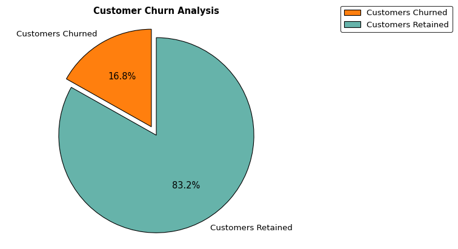

```python
#visualing the churn rate in percentages.

Cust_Churn_Count = (churn_clean['Churn'] == 1).sum()
Cust_Retained_count = (churn_clean['Churn'] == 0).sum()

# Defining the labels and sizes
labels = 'Customers Churned', 'Customers Retained'
sizes = [Cust_Churn_Count, Cust_Retained_count]
colors_given = ['#ff7f0e', '#66B3AA']

# Define the explode parameter (how much to pull apart the slices)
explode = (0.1, 0)  # Pull apart the first slice (Customer Left) by 10%
fig, ax = plt.subplots()

# Creating the pie chart
ax.pie(sizes, labels=labels, autopct='%1.1f%%', startangle=90, wedgeprops={'edgecolor': 'black'}, colors=colors_given, explode=explode)
ax.axis('equal')
legend_labels = ['Customers Churned', 'Customers Retained']

# Adding a legend
legend = ax.legend(legend_labels, title="", loc="center left", bbox_to_anchor=(1.1, 1))
legend.get_frame().set_edgecolor('black')

# Setting the title
plt.title('Customer Churn Analysis', fontweight='bold')
plt.show()
```

- The pie chart above shows that 16.8% of the total customer based churned while 83.2% are still using the services of the e-commerce company

```python
#checking out churn rate by gender distribution using a pivot table
churn_clean.pivot_table(values="Tenure", index="Gender", columns="Churn",
                      aggfunc='sum')
```

| Churn Gender | 0 | 1 |
| --- | --- | --- |
| Female | 22,011.00 | 946.00 |
| Male | 29,738.00 | 1,984.00 |

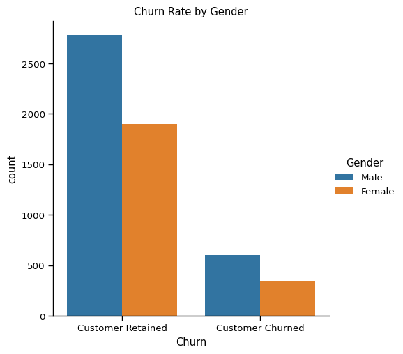

```python
#visualing the gender distibution with churn rate
sns.catplot(x = 'Churn', data = churn_1, hue = 'Gender', hue_order = ['Male', 'Female'],
            kind='count', palette=sns.color_palette('tab10'),
            order = ['Customer Retained', 'Customer Churned'])
plt.title("Churn Rate by Gender")
plt.show()
```

- The churn rate by gender plot reveals that, though there is a larger portion of male customers are still using the company's services compared to female customers, a high portion of these men still churned in comparism to their female conterpart.

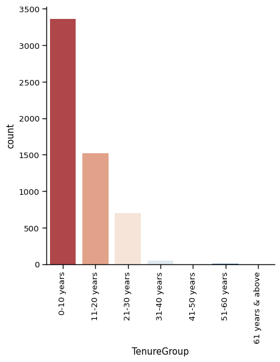

```python
sns.catplot(x='TenureGroup', data=churn_clean, kind='count',palette=sns.color_palette('RdBu'))
plt.xticks(rotation=90)
plt.show()
```

- The count plot shows the distribution of customers segmented into different tenure groups. Most of the customers fall into the category of those that have been with the company for less than 10 years.

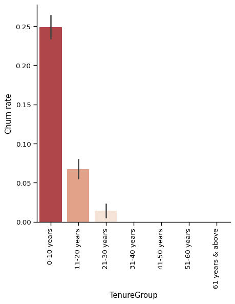

```python
sns.catplot(x='TenureGroup', y='Churn', data=churn_clean, kind='bar', palette=sns.color_palette('RdBu'))
plt.ylabel('Churn rate')
plt.xticks(rotation=90)
plt.show()
```

- The above plot shows the mean of customer's that churn per catergory with a 95% confidence interval.

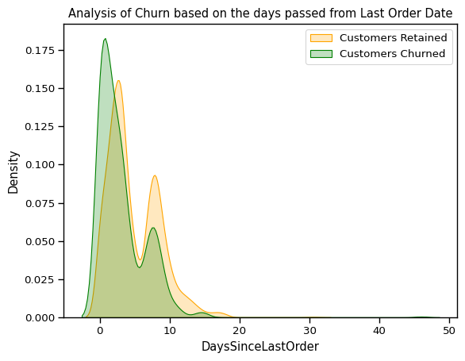

```python
sns.set_context("paper",font_scale=1.1)
ax = sns.kdeplot(churn_raw.DaySinceLastOrder[(churn_clean["Churn"] == 0) ],
                color="orange", shade = True);
ax = sns.kdeplot(churn_clean.DaySinceLastOrder[(churn_clean["Churn"] == 1) ],
                ax =ax, color="green", shade= True);
ax.legend(["Customers Retained","Customers Churned"],loc='upper right');
ax.set_ylabel('Density');
ax.set_xlabel('DaysSinceLastOrder');
ax.set_title('Analysis of Churn based on the days passed from Last Order Date');
```

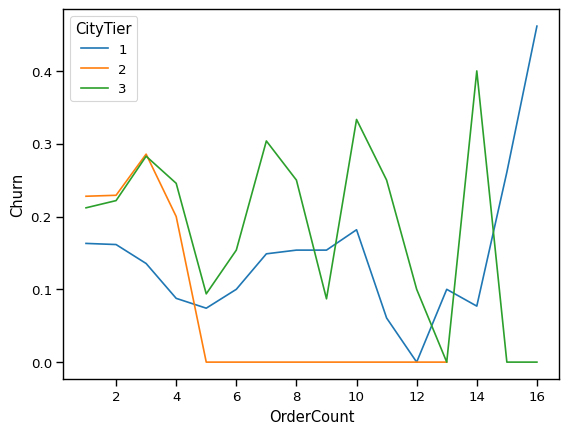

```python
palette = sns.color_palette('tab10')
sns.lineplot(
    data=churn_raw, x='OrderCount',  y="Churn",
    hue="CityTier", ci=None,
    palette=palette
)

#CityTier
```

- We see that for higher orders places, due to multiple reasons which could be operations, or availability of stock at warehouses , there is a high churn in tier. 1 and tier 3. Cities have the highest churn and it’s the lowers in tier 2

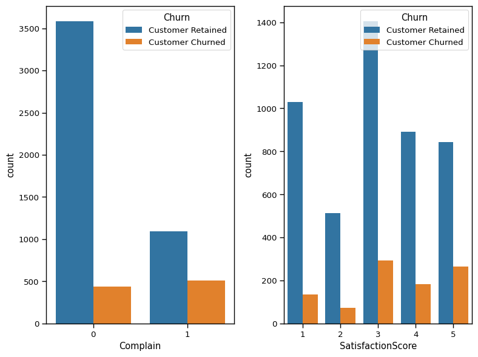

```python
order = ['Customer Retained', 'Customer Churned']

fig, axes = plt.subplots(1, 2, figsize=(8,6))
sns.countplot(data=churn_1, x='Complain', hue='Churn', ax=axes[0], hue_order=order)
sns.countplot(data=churn_1, x='SatisfactionScore', hue='Churn', ax=axes[1], hue_order=order)

plt.tight_layout()
```

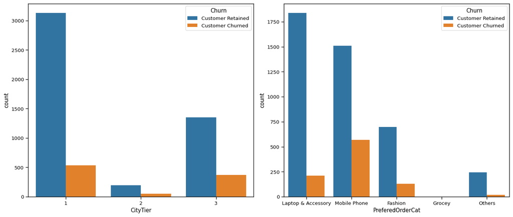

```python
fig, axes = plt.subplots(1, 2, figsize=(14, 6))
sns.countplot(data=churn_1, x='CityTier', hue='Churn', ax=axes[0], hue_order=order)
sns.countplot(data=churn_1, x='PreferedOrderCat', hue='Churn', ax=axes[1],
              order=['Laptop & Accessory', 'Mobile Phone', 'Fashion', 'Grocey', 'Others'],
              hue_order = order)
plt.tight_layout()
```

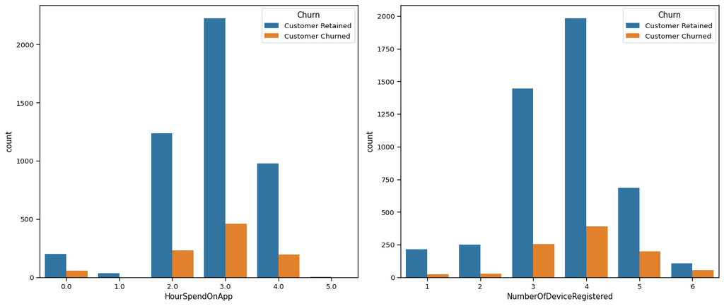

```python
fig, axes = plt.subplots(1, 2, figsize=(14, 6))
sns.countplot(data=churn_1, x='HourSpendOnApp', hue='Churn', ax=axes[0], hue_order=order)
sns.countplot(data=churn_1, x='NumberOfDeviceRegistered', hue='Churn', ax=axes[1], hue_order=order)
plt.tight_layout()
```

```python
#subsetting the dataset to determine the churn characteristics of customer that registered a complaint with the company
count_of_complaints=churn_clean.groupby(['Complain','Churn']).apply(lambda x:x['Churn'].count()).reset_index(name='No. of Customers')
count_of_complaints
```

|  | Complain | Churn | No. of Customers |
| --- | --- | --- | --- |
| 0 | 0 | 0 | 3586 |
| 1 | 0 | 1 | 440 |
| 2 | 1 | 0 | 1096 |
| 3 | 1 | 1 | 508 |

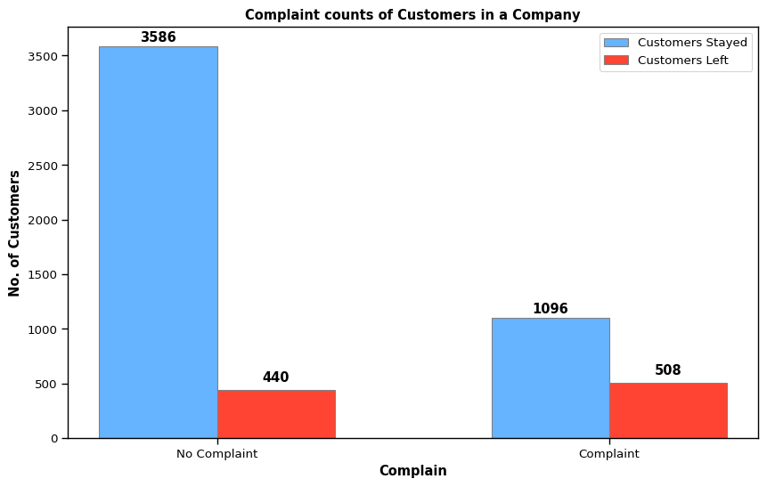

```python
complain_values = [0, 1]
churn_0 = [3586, 1096]  # Customer Retained
churn_1 = [440, 508]    # Customer Churned

complain_labels = ['No Complaint', 'Complaint']
bar_width = 0.30

r1 = range(len(complain_values))
r2 = [x + bar_width for x in r1]

fig, ax = plt.subplots(figsize=(10, 6))

plt.bar(r1, churn_0, color='#66B3FF', width=bar_width, edgecolor='grey', label='Customers Stayed')
plt.bar(r2, churn_1, color='#FF4433', width=bar_width, edgecolor='grey', label='Customers Left')


for i in range(len(complain_values)):
    plt.text(r1[i], churn_0[i] + 20, str(churn_0[i]), ha='center', va='bottom', color='black', fontweight='bold')
    plt.text(r2[i], churn_1[i] + 50, str(churn_1[i]), ha='center', va='bottom', color='black', fontweight='bold')

plt.xlabel('Complain', fontweight='bold')
plt.xticks([r + bar_width/2 for r in range(len(complain_values))], complain_labels)

plt.ylabel('No. of Customers', fontweight='bold')

plt.title('Complaint counts of Customers in a Company', fontweight='bold')

plt.legend()

plt.show()
```

# ML model - Decision Tree, Logistic Regression

```python
# Import all the libraries for machine learning models

from sklearn.model_selection import train_test_split
from sklearn.linear_model import LogisticRegression
from sklearn.tree import DecisionTreeClassifier
from sklearn.metrics import confusion_matrix,accuracy_score,classification_report,precision_score,recall_score,f1_score
import category_encoders as ce
from sklearn import tree
from sklearn.preprocessing import MinMaxScaler, OneHotEncoder, LabelEncoder
```

```python
churn_clean.nunique()
```

```
CustomerID                     5630
Churn                             2
Tenure                           36
PreferredLoginDevice              2
CityTier                          3
WarehouseToHome                  35
PreferredPaymentMode              5
Gender                            2
HourSpendOnApp                    6
NumberOfDeviceRegistered          6
PreferedOrderCat                  5
SatisfactionScore                 5
MaritalStatus                     3
NumberOfAddress                  15
Complain                          2
OrderAmountHikeFromlastYear      17
CouponUsed                       17
OrderCount                       17
DaySinceLastOrder                22
CashbackAmount                  220
cashback_grp                      4
TenureGroup                       7
dtype: int64
```

```python
churn_clean.info()
```

```
<class 'pandas.core.frame.DataFrame'>
RangeIndex: 5630 entries, 0 to 5629
Data columns (total 22 columns):
 #   Column                       Non-Null Count  Dtype
---  ------                       --------------  -----
 0   CustomerID                   5630 non-null   int64
 1   Churn                        5630 non-null   int64
 2   Tenure                       5630 non-null   float64
 3   PreferredLoginDevice         5630 non-null   object
 4   CityTier                     5630 non-null   int64
 5   WarehouseToHome              5630 non-null   float64
 6   PreferredPaymentMode         5630 non-null   object
 7   Gender                       5630 non-null   object
 8   HourSpendOnApp               5630 non-null   float64
 9   NumberOfDeviceRegistered     5630 non-null   int64
 10  PreferedOrderCat             5630 non-null   object
 11  SatisfactionScore            5630 non-null   int64
 12  MaritalStatus                5630 non-null   object
 13  NumberOfAddress              5630 non-null   int64
 14  Complain                     5630 non-null   int64
 15  OrderAmountHikeFromlastYear  5630 non-null   float64
 16  CouponUsed                   5630 non-null   float64
 17  OrderCount                   5630 non-null   float64
 18  DaySinceLastOrder            5630 non-null   float64
 19  CashbackAmount               5630 non-null   int64
 20  cashback_grp                 5626 non-null   category
 21  TenureGroup                  5630 non-null   category
dtypes: category(2), float64(7), int64(8), object(5)
memory usage: 891.4+ KB
```

```python
#converting the category dtype of TenureGroup column to numerical value
encoder = ce.OrdinalEncoder(mapping=[{'col': 'TenureGroup', 'mapping': {'0-10 years': 1, '11-20 years': 2, '21-30 years':3,
                                                                       '31-40 years': 4, '41-50 years': 5, '51-60 years': 6,
                                                                       '61 years & above': 7}}])

encoder.fit(churn_clean)
churn_clean = encoder.transform(churn_clean)
churn_clean.head(10)
```

|  | CustomerID | Churn | Tenure | PreferredLoginDevice | CityTier | WarehouseToHome | PreferredPaymentMode | Gender | HourSpendOnApp | NumberOfDeviceRegistered | ... | MaritalStatus | NumberOfAddress | Complain | OrderAmountHikeFromlastYear | CouponUsed | OrderCount | DaySinceLastOrder | CashbackAmount | cashback_grp | TenureGroup |
| --- | --- | --- | --- | --- | --- | --- | --- | --- | --- | --- | --- | --- | --- | --- | --- | --- | --- | --- | --- | --- | --- |
| 0 | 50001 | 1 | 4.00 | Mobile Phone | 3 | 6.00 | Debit Card | Female | 3.00 | 3 | ... | Single | 9 | 1 | 11.00 | 1.00 | 1.00 | 5.00 | 160 | 100-200 | 1 |
| 1 | 50002 | 1 | 0.00 | Mobile Phone | 1 | 8.00 | UPI | Male | 3.00 | 4 | ... | Single | 7 | 1 | 15.00 | 0.00 | 1.00 | 0.00 | 121 | 100-200 | 1 |
| 2 | 50003 | 1 | 0.00 | Mobile Phone | 1 | 30.00 | Debit Card | Male | 2.00 | 4 | ... | Single | 6 | 1 | 14.00 | 0.00 | 1.00 | 3.00 | 120 | 100-200 | 1 |
| 3 | 50004 | 1 | 0.00 | Mobile Phone | 3 | 15.00 | Debit Card | Male | 2.00 | 4 | ... | Single | 8 | 0 | 23.00 | 0.00 | 1.00 | 3.00 | 134 | 100-200 | 1 |
| 4 | 50005 | 1 | 0.00 | Mobile Phone | 1 | 12.00 | Credit Card | Male | 0.00 | 3 | ... | Single | 3 | 0 | 11.00 | 1.00 | 1.00 | 3.00 | 130 | 100-200 | 1 |
| 5 | 50006 | 1 | 0.00 | Computer | 1 | 22.00 | Debit Card | Female | 3.00 | 5 | ... | Single | 2 | 1 | 22.00 | 4.00 | 6.00 | 7.00 | 139 | 100-200 | 1 |
| 6 | 50007 | 1 | 0.00 | Mobile Phone | 3 | 11.00 | Cash on Delivery | Male | 2.00 | 3 | ... | Divorced | 4 | 0 | 14.00 | 0.00 | 1.00 | 0.00 | 121 | 100-200 | 1 |
| 7 | 50008 | 1 | 0.00 | Mobile Phone | 1 | 6.00 | Credit Card | Male | 3.00 | 3 | ... | Divorced | 3 | 1 | 16.00 | 2.00 | 2.00 | 0.00 | 123 | 100-200 | 1 |
| 8 | 50009 | 1 | 13.00 | Mobile Phone | 3 | 9.00 | E wallet | Male | 0.00 | 4 | ... | Divorced | 2 | 1 | 14.00 | 0.00 | 1.00 | 2.00 | 127 | 100-200 | 2 |
| 9 | 50010 | 1 | 0.00 | Mobile Phone | 1 | 31.00 | Debit Card | Male | 2.00 | 5 | ... | Single | 2 | 0 | 12.00 | 1.00 | 1.00 | 1.00 | 123 | 100-200 | 1 |

10 rows × 22 columns

```python
churn_clean['TenureGroup'].unique()
```

```
array([1, 2, 3, 5, 6, 4, 7])
```

```python
#importing libraries for preprocessing
from sklearn.preprocessing import LabelEncoder
from sklearn.preprocessing import StandardScaler
```

```python
#defining coloumns (target column, needed for encoding later)
cust_id = ['CustomerID']
Target = ["Churn"]

#creating categorical list columns with unique values less than 7
cat_variable = churn_clean.nunique()[churn_clean.nunique() < 7].keys().tolist()
cat_variable = [x for x in cat_variable if x not in Target]

#creating numnerical list columns
numerical_vari = [x for x in churn_clean if x not in cat_variable + Target + cust_id]

#separating columns with only 2 unique values as binary
binary_vari = churn_clean.nunique()[churn_clean.nunique() == 2].keys().tolist()

#separating rest into multiple
more_then_2_vari = [i for i in cat_variable if i not in binary_vari]
```

```python
#label encoding binary columns
lab_encod = LabelEncoder()
for x in binary_vari:
    churn_clean[x] = lab_encod.fit_transform(churn_clean[x])
```

```python
churn_clean = pd.get_dummies(churn_clean, columns=more_then_2_vari)
```

```python
#standardizing numerical columns for preprocessing
scaler = StandardScaler()
numerical_cols = ["Tenure", "WarehouseToHome", "NumberOfAddress", "CashbackAmount"]
churn_clean[numerical_cols] = scaler.fit_transform(churn_clean[numerical_cols])
```

```python
#summary
churn_clean.describe().transpose()
```

|  | count | mean | std | min | 25% | 50% | 75% | max |
| --- | --- | --- | --- | --- | --- | --- | --- | --- |
| CustomerID | 5,630.00 | 52,815.50 | 1,625.39 | 50,001.00 | 51,408.25 | 52,815.50 | 54,222.75 | 55,630.00 |
| Churn | 5,630.00 | 0.17 | 0.37 | 0.00 | 0.00 | 0.00 | 0.00 | 1.00 |
| Tenure | 5,630.00 | 0.00 | 1.00 | -1.13 | -1.01 | -0.20 | 0.61 | 5.95 |
| PreferredLoginDevice | 5,630.00 | 0.71 | 0.45 | 0.00 | 0.00 | 1.00 | 1.00 | 1.00 |
| WarehouseToHome | 5,630.00 | 0.00 | 1.00 | -1.67 | -0.66 | -0.22 | 0.57 | 12.53 |
| Gender | 5,630.00 | 0.60 | 0.49 | 0.00 | 0.00 | 1.00 | 1.00 | 1.00 |
| NumberOfAddress | 5,630.00 | 0.00 | 1.00 | -1.24 | -0.86 | -0.47 | 0.69 | 6.88 |
| Complain | 5,630.00 | 0.28 | 0.45 | 0.00 | 0.00 | 0.00 | 1.00 | 1.00 |
| OrderAmountHikeFromlastYear | 5,630.00 | 14.97 | 4.89 | 0.00 | 13.00 | 14.00 | 18.00 | 26.00 |
| CouponUsed | 5,630.00 | 1.67 | 1.89 | 0.00 | 1.00 | 1.00 | 2.00 | 16.00 |
| OrderCount | 5,630.00 | 2.87 | 2.94 | 0.00 | 1.00 | 2.00 | 3.00 | 16.00 |
| DaySinceLastOrder | 5,630.00 | 4.30 | 3.70 | 0.00 | 1.00 | 3.00 | 7.00 | 46.00 |
| CashbackAmount | 5,630.00 | 0.00 | 1.00 | -3.60 | -0.63 | -0.29 | 0.38 | 3.00 |
| TenureGroup | 5,630.00 | 1.55 | 0.75 | 1.00 | 1.00 | 1.00 | 2.00 | 7.00 |

```python
#calculating coorelation
corr_churn = churn_clean.corr()
matrix_cols = corr_churn.columns.tolist()
corr_array = np.array(corr_churn)
corr_churn
```

|  | CustomerID | Churn | Tenure | PreferredLoginDevice | WarehouseToHome | Gender | NumberOfAddress | Complain | OrderAmountHikeFromlastYear | CouponUsed | ... | SatisfactionScore_3 | SatisfactionScore_4 | SatisfactionScore_5 | MaritalStatus_Divorced | MaritalStatus_Married | MaritalStatus_Single | cashback_grp_0-99 | cashback_grp_100-200 | cashback_grp_201-300 | cashback_grp_301+ |
| --- | --- | --- | --- | --- | --- | --- | --- | --- | --- | --- | --- | --- | --- | --- | --- | --- | --- | --- | --- | --- | --- |
| CustomerID | 1.00 | -0.02 | 0.08 | -0.00 | 0.12 | 0.00 | 0.16 | -0.01 | 0.03 | 0.24 | ... | -0.00 | 0.01 | 0.01 | -0.24 | 0.18 | -0.01 | 0.01 | -0.08 | 0.03 | 0.14 |
| Churn | -0.02 | 1.00 | -0.35 | -0.05 | 0.03 | 0.03 | 0.04 | 0.25 | 0.04 | 0.01 | ... | 0.01 | 0.00 | 0.09 | -0.02 | -0.15 | 0.18 | -0.02 | 0.10 | -0.09 | -0.04 |
| Tenure | 0.08 | -0.35 | 1.00 | 0.04 | 0.02 | -0.05 | 0.25 | -0.02 | -0.18 | 0.10 | ... | 0.00 | 0.01 | -0.03 | 0.04 | 0.08 | -0.12 | -0.01 | -0.44 | 0.37 | 0.21 |
| PreferredLoginDevice | -0.00 | -0.05 | 0.04 | 1.00 | -0.02 | -0.02 | 0.03 | 0.00 | -0.04 | -0.02 | ... | -0.04 | 0.01 | 0.04 | 0.03 | -0.00 | -0.02 | 0.00 | -0.04 | 0.03 | 0.03 |
| WarehouseToHome | 0.12 | 0.03 | 0.02 | -0.02 | 1.00 | -0.00 | 0.01 | 0.02 | 0.04 | 0.03 | ... | 0.01 | 0.00 | 0.00 | -0.00 | 0.04 | -0.04 | 0.01 | -0.05 | 0.06 | -0.03 |
| Gender | 0.00 | 0.03 | -0.05 | -0.02 | -0.00 | 1.00 | -0.03 | -0.04 | -0.02 | -0.03 | ... | -0.01 | -0.03 | -0.01 | -0.01 | 0.04 | -0.03 | -0.02 | 0.03 | -0.04 | 0.02 |
| NumberOfAddress | 0.16 | 0.04 | 0.25 | 0.03 | 0.01 | -0.03 | 1.00 | -0.03 | -0.04 | 0.03 | ... | -0.01 | 0.03 | 0.03 | -0.00 | 0.01 | -0.01 | -0.02 | -0.13 | 0.11 | 0.06 |
| Complain | -0.01 | 0.25 | -0.02 | 0.00 | 0.02 | -0.04 | -0.03 | 1.00 | 0.01 | -0.01 | ... | -0.01 | -0.04 | 0.01 | 0.01 | -0.00 | -0.00 | 0.02 | -0.01 | 0.02 | -0.01 |
| OrderAmountHikeFromlastYear | 0.03 | 0.04 | -0.18 | -0.04 | 0.04 | -0.02 | -0.04 | 0.01 | 1.00 | -0.09 | ... | -0.03 | -0.01 | 0.01 | -0.03 | -0.01 | 0.04 | 0.01 | 0.26 | -0.10 | -0.44 |
| CouponUsed | 0.24 | 0.01 | 0.10 | -0.02 | 0.03 | -0.03 | 0.03 | -0.01 | -0.09 | 1.00 | ... | -0.02 | 0.01 | 0.02 | 0.03 | 0.01 | -0.03 | 0.04 | -0.14 | 0.09 | 0.12 |
| OrderCount | 0.13 | -0.02 | 0.16 | -0.01 | 0.02 | -0.02 | -0.03 | -0.03 | -0.13 | 0.59 | ... | -0.01 | -0.00 | 0.02 | 0.02 | 0.03 | -0.05 | 0.04 | -0.22 | 0.16 | 0.16 |
| DaySinceLastOrder | 0.08 | -0.15 | 0.18 | 0.00 | 0.05 | -0.02 | -0.07 | -0.04 | -0.12 | 0.25 | ... | -0.02 | -0.00 | 0.04 | 0.01 | 0.04 | -0.05 | 0.00 | -0.12 | 0.06 | 0.14 |
| CashbackAmount | 0.22 | -0.15 | 0.51 | 0.05 | 0.07 | -0.03 | 0.19 | 0.00 | -0.38 | 0.17 | ... | -0.00 | 0.00 | 0.00 | 0.04 | 0.05 | -0.09 | -0.11 | -0.82 | 0.70 | 0.46 |
| TenureGroup | 0.05 | -0.25 | 0.93 | 0.04 | 0.02 | -0.04 | 0.23 | 0.00 | -0.17 | 0.06 | ... | 0.02 | 0.01 | -0.02 | 0.04 | 0.06 | -0.10 | -0.00 | -0.42 | 0.35 | 0.21 |
| CityTier_1 | -0.01 | -0.08 | 0.04 | -0.00 | -0.03 | 0.02 | 0.03 | -0.00 | 0.00 | -0.02 | ... | 0.04 | -0.04 | 0.01 | -0.01 | 0.02 | -0.01 | -0.00 | 0.02 | -0.03 | 0.02 |
| CityTier_2 | 0.02 | 0.02 | 0.01 | 0.01 | -0.01 | 0.04 | 0.01 | -0.01 | -0.05 | -0.03 | ... | -0.03 | 0.07 | -0.01 | -0.01 | 0.05 | -0.05 | -0.01 | 0.00 | -0.01 | 0.04 |
| CityTier_3 | -0.00 | 0.08 | -0.05 | -0.00 | 0.04 | -0.03 | -0.03 | 0.01 | 0.02 | 0.03 | ... | -0.03 | 0.01 | -0.01 | 0.02 | -0.04 | 0.03 | 0.01 | -0.02 | 0.03 | -0.04 |
| PreferredPaymentMode_Cash on Delivery | -0.00 | 0.07 | -0.02 | 0.02 | -0.02 | 0.01 | -0.01 | -0.02 | -0.01 | 0.02 | ... | 0.01 | 0.02 | -0.00 | 0.00 | -0.02 | 0.02 | -0.01 | 0.03 | -0.02 | -0.03 |
| PreferredPaymentMode_Credit Card | -0.00 | -0.05 | 0.00 | -0.00 | 0.01 | -0.02 | 0.02 | 0.00 | 0.00 | -0.02 | ... | 0.03 | -0.01 | 0.01 | -0.00 | 0.01 | -0.01 | 0.03 | -0.02 | 0.01 | 0.01 |
| PreferredPaymentMode_Debit Card | 0.00 | -0.03 | 0.02 | -0.03 | -0.03 | 0.00 | -0.00 | -0.01 | 0.02 | -0.00 | ... | 0.02 | -0.05 | -0.02 | -0.01 | -0.02 | 0.02 | -0.01 | 0.01 | -0.01 | 0.00 |
| PreferredPaymentMode_E wallet | -0.01 | 0.06 | 0.02 | 0.04 | 0.05 | -0.02 | -0.02 | 0.01 | -0.02 | 0.01 | ... | -0.06 | 0.06 | 0.01 | 0.02 | 0.00 | -0.02 | 0.00 | -0.04 | 0.04 | -0.00 |
| PreferredPaymentMode_UPI | 0.01 | 0.00 | -0.04 | 0.00 | 0.00 | 0.04 | 0.00 | 0.02 | -0.01 | -0.00 | ... | -0.03 | 0.03 | 0.01 | -0.01 | 0.04 | -0.03 | -0.01 | 0.04 | -0.04 | 0.01 |
| HourSpendOnApp_0.0 | -0.19 | 0.03 | -0.10 | -0.00 | -0.01 | 0.02 | -0.11 | -0.01 | 0.02 | -0.08 | ... | 0.01 | -0.00 | -0.01 | -0.01 | 0.01 | -0.01 | -0.01 | 0.12 | -0.11 | -0.04 |
| HourSpendOnApp_1.0 | -0.06 | -0.04 | 0.03 | -0.03 | -0.01 | -0.02 | -0.03 | -0.01 | 0.02 | -0.02 | ... | 0.00 | -0.00 | 0.00 | -0.00 | -0.01 | 0.01 | -0.00 | 0.00 | 0.01 | -0.01 |
| HourSpendOnApp_2.0 | -0.49 | -0.02 | -0.00 | -0.01 | -0.09 | 0.02 | -0.11 | -0.00 | -0.04 | -0.15 | ... | 0.00 | 0.00 | -0.03 | -0.01 | -0.03 | 0.04 | -0.02 | 0.02 | 0.02 | -0.09 |
| HourSpendOnApp_3.0 | 0.16 | 0.01 | 0.01 | 0.01 | 0.02 | -0.00 | 0.05 | 0.01 | -0.01 | 0.04 | ... | 0.00 | 0.00 | 0.00 | 0.00 | -0.00 | -0.00 | 0.01 | -0.04 | 0.02 | 0.05 |
| HourSpendOnApp_4.0 | 0.45 | -0.00 | 0.03 | 0.01 | 0.08 | -0.02 | 0.11 | 0.00 | 0.04 | 0.16 | ... | -0.01 | -0.00 | 0.03 | 0.01 | 0.03 | -0.04 | 0.02 | -0.03 | 0.01 | 0.05 |
| HourSpendOnApp_5.0 | 0.02 | -0.01 | 0.01 | 0.01 | 0.01 | -0.01 | 0.01 | -0.01 | 0.01 | 0.03 | ... | -0.02 | 0.01 | 0.01 | -0.01 | -0.01 | 0.02 | -0.00 | 0.01 | -0.01 | -0.00 |
| NumberOfDeviceRegistered_1 | -0.15 | -0.04 | -0.01 | 0.01 | -0.03 | 0.02 | -0.05 | -0.00 | 0.01 | -0.06 | ... | 0.01 | -0.01 | 0.02 | -0.03 | 0.05 | -0.03 | -0.01 | 0.04 | -0.03 | -0.03 |
| NumberOfDeviceRegistered_2 | 0.14 | -0.05 | 0.02 | 0.01 | 0.03 | 0.02 | 0.03 | -0.00 | 0.03 | 0.03 | ... | -0.00 | -0.01 | 0.02 | 0.00 | 0.03 | -0.03 | -0.01 | 0.01 | -0.01 | -0.01 |
| NumberOfDeviceRegistered_3 | -0.55 | -0.03 | -0.03 | -0.00 | -0.07 | 0.00 | -0.10 | 0.00 | -0.03 | -0.18 | ... | -0.00 | -0.00 | -0.01 | 0.02 | -0.01 | -0.01 | -0.00 | 0.07 | -0.03 | -0.10 |
| NumberOfDeviceRegistered_4 | 0.29 | -0.01 | 0.04 | 0.00 | 0.03 | -0.01 | 0.07 | -0.00 | -0.02 | 0.09 | ... | -0.00 | 0.01 | -0.01 | 0.00 | -0.01 | 0.01 | 0.02 | -0.05 | 0.02 | 0.08 |
| NumberOfDeviceRegistered_5 | 0.23 | 0.06 | -0.01 | -0.00 | 0.03 | -0.01 | 0.04 | 0.00 | 0.02 | 0.09 | ... | -0.00 | 0.01 | -0.00 | -0.01 | -0.01 | 0.02 | -0.02 | -0.05 | 0.04 | 0.03 |
| NumberOfDeviceRegistered_6 | 0.15 | 0.08 | -0.03 | -0.03 | 0.03 | 0.01 | 0.02 | 0.01 | 0.04 | 0.06 | ... | 0.01 | -0.03 | -0.01 | -0.02 | 0.01 | 0.01 | 0.02 | -0.00 | -0.01 | 0.04 |
| PreferedOrderCat_Fashion | -0.01 | -0.01 | 0.12 | 0.02 | 0.06 | -0.03 | 0.04 | 0.01 | 0.07 | 0.14 | ... | -0.01 | -0.01 | 0.02 | 0.00 | 0.03 | -0.03 | -0.02 | -0.42 | 0.47 | -0.07 |
| PreferedOrderCat_Grocery | 0.00 | -0.09 | 0.35 | 0.01 | 0.05 | -0.05 | 0.07 | 0.01 | -0.13 | 0.01 | ... | -0.02 | 0.01 | 0.00 | 0.04 | 0.01 | -0.04 | 0.01 | -0.51 | 0.52 | 0.02 |
| PreferedOrderCat_Laptop & Accessory | 0.01 | -0.13 | -0.02 | -0.05 | 0.09 | -0.02 | 0.04 | -0.02 | 0.11 | -0.01 | ... | 0.01 | -0.03 | -0.00 | -0.01 | 0.03 | -0.03 | 0.01 | 0.34 | -0.31 | -0.12 |
| PreferedOrderCat_Mobile Phone | -0.00 | 0.22 | -0.37 | 0.01 | -0.14 | 0.05 | -0.14 | 0.01 | 0.13 | -0.12 | ... | -0.00 | 0.02 | -0.00 | -0.02 | -0.07 | 0.09 | 0.00 | 0.42 | -0.39 | -0.13 |
| PreferedOrderCat_Others | -0.01 | -0.05 | 0.27 | 0.05 | -0.05 | 0.03 | 0.05 | -0.01 | -0.49 | 0.05 | ... | 0.03 | 0.02 | -0.03 | 0.02 | 0.03 | -0.04 | -0.01 | -0.40 | 0.16 | 0.66 |
| SatisfactionScore_1 | 0.14 | -0.07 | 0.01 | -0.02 | -0.00 | 0.03 | -0.04 | 0.04 | 0.03 | -0.01 | ... | -0.34 | -0.25 | -0.25 | -0.21 | 0.14 | 0.02 | 0.03 | 0.01 | -0.01 | -0.01 |
| SatisfactionScore_2 | -0.20 | -0.04 | -0.00 | 0.01 | -0.02 | 0.01 | -0.01 | 0.00 | 0.01 | 0.01 | ... | -0.22 | -0.17 | -0.17 | 0.27 | -0.22 | 0.02 | 0.00 | -0.01 | 0.01 | -0.01 |
| SatisfactionScore_3 | -0.00 | 0.01 | 0.00 | -0.04 | 0.01 | -0.01 | -0.01 | -0.01 | -0.03 | -0.02 | ... | 1.00 | -0.32 | -0.33 | 0.02 | 0.01 | -0.02 | -0.02 | 0.01 | -0.02 | 0.02 |
| SatisfactionScore_4 | 0.01 | 0.00 | 0.01 | 0.01 | 0.00 | -0.03 | 0.03 | -0.04 | -0.01 | 0.01 | ... | -0.32 | 1.00 | -0.24 | -0.01 | 0.01 | 0.00 | -0.01 | -0.01 | 0.01 | 0.01 |
| SatisfactionScore_5 | 0.01 | 0.09 | -0.03 | 0.04 | 0.00 | -0.01 | 0.03 | 0.01 | 0.01 | 0.02 | ... | -0.33 | -0.24 | 1.00 | -0.00 | 0.01 | -0.01 | 0.01 | -0.01 | 0.01 | -0.01 |
| MaritalStatus_Divorced | -0.24 | -0.02 | 0.04 | 0.03 | -0.00 | -0.01 | -0.00 | 0.01 | -0.03 | 0.03 | ... | 0.02 | -0.01 | -0.00 | 1.00 | -0.45 | -0.29 | -0.02 | -0.04 | 0.03 | 0.02 |
| MaritalStatus_Married | 0.18 | -0.15 | 0.08 | -0.00 | 0.04 | 0.04 | 0.01 | -0.00 | -0.01 | 0.01 | ... | 0.01 | 0.01 | 0.01 | -0.45 | 1.00 | -0.73 | 0.04 | -0.05 | 0.04 | 0.02 |
| MaritalStatus_Single | -0.01 | 0.18 | -0.12 | -0.02 | -0.04 | -0.03 | -0.01 | -0.00 | 0.04 | -0.03 | ... | -0.02 | 0.00 | -0.01 | -0.29 | -0.73 | 1.00 | -0.03 | 0.08 | -0.07 | -0.04 |
| cashback_grp_0-99 | 0.01 | -0.02 | -0.01 | 0.00 | 0.01 | -0.02 | -0.02 | 0.02 | 0.01 | 0.04 | ... | -0.02 | -0.01 | 0.01 | -0.02 | 0.04 | -0.03 | 1.00 | -0.07 | -0.02 | -0.01 |
| cashback_grp_100-200 | -0.08 | 0.10 | -0.44 | -0.04 | -0.05 | 0.03 | -0.13 | -0.01 | 0.26 | -0.14 | ... | 0.01 | -0.01 | -0.01 | -0.04 | -0.05 | 0.08 | -0.07 | 1.00 | -0.92 | -0.30 |
| cashback_grp_201-300 | 0.03 | -0.09 | 0.37 | 0.03 | 0.06 | -0.04 | 0.11 | 0.02 | -0.10 | 0.09 | ... | -0.02 | 0.01 | 0.01 | 0.03 | 0.04 | -0.07 | -0.02 | -0.92 | 1.00 | -0.08 |
| cashback_grp_301+ | 0.14 | -0.04 | 0.21 | 0.03 | -0.03 | 0.02 | 0.06 | -0.01 | -0.44 | 0.12 | ... | 0.02 | 0.01 | -0.01 | 0.02 | 0.02 | -0.04 | -0.01 | -0.30 | -0.08 | 1.00 |

51 rows × 51 columns

```python
from sklearn.model_selection import train_test_split
from sklearn.linear_model import LogisticRegression
from sklearn.tree import DecisionTreeClassifier
from sklearn.metrics import confusion_matrix,accuracy_score,classification_report,precision_score,recall_score,f1_score
import category_encoders as ce
from sklearn import tree
from sklearn.preprocessing import MinMaxScaler, OneHotEncoder, LabelEncoder
```

```python
#splitting dataset into train and test data
train,test = train_test_split(churn_clean,test_size = .20 ,random_state = 0)

cols    = [i for i in churn_clean.columns if i not in cust_id + Target]
X_train = train[cols]
Y_train = train[Target]
X_test  = test[cols]
Y_test  = test[Target]
```

```
Accuracy: 0.8801065719360568

Precision: 0.7096774193548387

Recall: 0.47058823529411764

F1 Score: 0.5659163987138264

Confusion Matrix:
[[903  36]
 [ 99  88]]

Test Data Accuracy: 0.880107
```

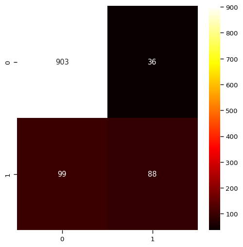

```python
#logistic Regression
# Create an instance of the LogisticRegression model
logistic_regression_model = LogisticRegression(random_state=0)

# Fit the model to the training data
logistic_regression_model.fit(X_train, Y_train)

# Make predictions on the test data
Y_pred = logistic_regression_model.predict(X_test)

# Evaluate the model's performance
accuracy = accuracy_score(Y_test, Y_pred)
precision = precision_score(Y_test, Y_pred)
recall = recall_score(Y_test, Y_pred)
f1 = f1_score(Y_test, Y_pred)

# Print the evaluation metrics
print("Accuracy:", accuracy)
print("")
print("Precision:", precision)
print("")
print("Recall:", recall)
print("")
print("F1 Score:", f1)
print("")

# Generate a confusion matrix
confusion_matrix_result = confusion_matrix(Y_test, Y_pred)
print("Confusion Matrix:")
print(confusion_matrix_result)
print("")

df_cm = pd.DataFrame(confusion_matrix_result, index = (0, 1), columns = (0, 1))
plt.figure(figsize = (6,6))
sns.heatmap(df_cm, annot = True, fmt ='g', cmap='hot')
print("Test Data Accuracy: %.6f" %accuracy_score(Y_test, Y_pred))
```

```python
# Generate a classification report
classification_report_result = classification_report(Y_test, Y_pred)
print("Classification Report:")
print(classification_report_result)
```

```
Classification Report:
              precision    recall  f1-score   support

           0       0.90      0.96      0.93       939
           1       0.71      0.47      0.57       187

    accuracy                           0.88      1126
   macro avg       0.81      0.72      0.75      1126
weighted avg       0.87      0.88      0.87      1126
```

## Decision Tree Classifier

```
Accuracy: 0.9298401420959147
Precision: 0.7654867256637168
Recall: 0.8693467336683417
```

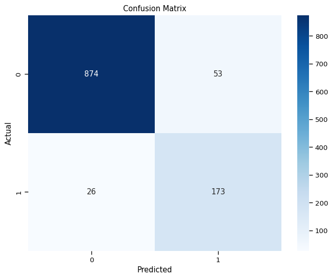

```python
#Building our model using Decision Tree Classifer
X = churn_clean.drop(['Churn'],axis=1)
y = churn_clean['Churn']

X_train, X_test, y_train, y_test = train_test_split(X, y, test_size=0.2, random_state=128)

deci_tree = DecisionTreeClassifier()
deci_tree.fit(X_train,y_train)
deci_tree_pred = deci_tree.predict(X_test)
recall_score(y_test, deci_tree_pred)

# Calculate and print accuracy
accuracy_dt = accuracy_score(y_test, deci_tree_pred)
precision_dt = precision_score(y_test, deci_tree_pred)
recall_dt = recall_score(y_test, deci_tree_pred)
print("Accuracy:", accuracy_dt)
print("Precision:", precision_dt)
print("Recall:", recall_dt)

#confusion matrix
conf_matrix = confusion_matrix(y_test, deci_tree_pred)
plt.figure(figsize=(8, 6))
sns.heatmap(conf_matrix, annot=True, fmt="d", cmap="Blues")
plt.xlabel("Predicted")
plt.ylabel("Actual")
plt.title("Confusion Matrix")
plt.show()
```

```python
#classification report for decision tree
class_report = classification_report(y_test, deci_tree_pred)
print("Classification Report for Decision Tree:\n", class_report)
```

```
Classification Report for Decision Tree:
               precision    recall  f1-score   support

           0       0.97      0.94      0.96       927
           1       0.77      0.87      0.81       199

    accuracy                           0.93      1126
   macro avg       0.87      0.91      0.89      1126
weighted avg       0.93      0.93      0.93      1126
```

```python
from rfpimp import *
```

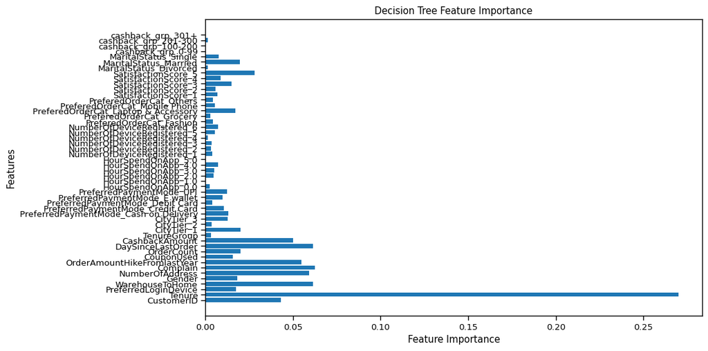

```python
#generating future importance
feature_importance1 = deci_tree.feature_importances_
feature_names2 = X.columns

# Create a bar plot to visualize feature importance
plt.figure(figsize=(10, 6))
plt.barh(feature_names2, feature_importance1)
plt.xlabel('Feature Importance')
plt.ylabel('Features')
plt.title('Decision Tree Feature Importance')
plt.show()
```